# Introduction to ggplot2

Thomas Carroll

3 May 2016

## ggplot2 is just “plot lego”

Building blocks of a ggplot2 graph

-data

-mapping/aes

-geoms

-scales -theme -stat

## Overview of a ggplot2 command

## Getting started with ggplot2

Earlier we have been working with the patient’s dataset to create a “clean and tidy” dataset.

Now we will use this dataset to demonstrate some of the plotting capabilities of ggplot2.

First lets load the data and perform the clean and tidy.

```r
library(tidyr)
library(ggplot2)
library(dplyr)
library(stringr)
library(lubridate)
patients <- read.delim("patient-data.txt")
patients_clean <- mutate(patients, Sex = factor(str_trim(Sex)))
patients_clean <- mutate(patients_clean, ID=str_pad(patients_clean$ID,pad = "0",width=3))
patients_clean <- mutate(patients_clean, Height= as.numeric(str_replace_all(patients_clean$Height,pattern = "cm","")))

grds <- patients$Grade_Level
patients_clean <- mutate(patients_clean, Grade = ifelse(grds == 99, NA,grds))

dob <- ymd(patients$Birth)
today <- ymd("20160509")
age <- interval(dob, today)
patients_clean <- mutate(patients_clean, Age = year(as.period(age)))

patients_clean <- mutate(patients_clean, Weight = as.numeric(str_replace_all(patients_clean$Weight,"kg","")))

patients_clean <- mutate(patients_clean, BMI = (Weight/(Height/100)^2), Overweight = BMI > 25)

patients_clean <- mutate(patients_clean, Smokes = str_replace_all(Smokes, "Yes|TRUE", "Smoker"))
patients_clean <- mutate(patients_clean, Smokes = str_replace_all(Smokes, "No|FALSE", "Non-Smoker"))

patients_clean <- mutate(patients_clean, Pet = str_to_title(Pet))
patients_clean <- mutate(patients_clean, Pet = str_replace_all(Pet, "Null","NA"))
patients_clean <- mutate(patients_clean, Pet = str_replace_na(Pet))

patients_clean <- mutate(patients_clean, Race = str_replace_na(Race))

patients_clean <- mutate(patients_clean, ID = str_c("Patient-",ID))


summary(patients_clean)
write.table(patients_clean,"patients_clean_ggplot2.txt",sep="\t",row.names=F,quote=F)
```

Now our data is clean and tidy.

```r
patients_clean <- read.delim("patients_clean_ggplot2.txt",sep="\t")
knitr:::kable(head(patients_clean))
```

| ID | Name | Race | Age | Sex | Smokes | Height | Weight | Birth | State | Pet | Grade_Level | Died | Count | Date | Grade | BMI | Overweight |
| --- | --- | --- | --- | --- | --- | --- | --- | --- | --- | --- | --- | --- | --- | --- | --- | --- | --- |
| Patient-001 | Demetrius | White | 44 | Male | Smoker | 176.4791 | 77.07070 | 1972-02-11 | New York | Cat | 1 | TRUE | -0.7440011 | 2015-03-04 | 1 | 24.74586 | FALSE |
| Patient-002 | Rosario | White | 43 | Male | Smoker | 174.7485 | 83.26835 | 1972-07-22 | Florida | Cat | 1 | TRUE | -1.0714531 | 2015-03-04 | 1 | 27.26799 | TRUE |
| Patient-003 | Julio | Black | 44 | Male | Non-Smoker | 173.9449 | 85.63231 | 1971-11-23 | Connecticut | Dog | 2 | FALSE | -0.8215636 | 2015-03-04 | 2 | 28.30182 | TRUE |
| Patient-004 | Lupe | White | 44 | Male | Non-Smoker | 180.0289 | 88.72032 | 1971-10-03 | Massachusetts | Dog | 1 | TRUE | 0.4976671 | 2015-03-04 | 1 | 27.37403 | TRUE |
| Patient-005 | Lavern | Cat | 43 | Male | Non-Smoker | 178.6365 | 97.05405 | 1972-11-23 | Kansas | Cat | 3 | FALSE | -1.2099217 | 2015-03-04 | 3 | 30.41397 | TRUE |
| Patient-006 | Bernie | Native | 43 | Female | Non-Smoker | 159.7778 | 68.31247 | 1972-07-30 | Illinois | Cat | 2 | FALSE | 0.5241618 | 2015-03-04 | 2 | 26.75882 | TRUE |

### Our first ggplot2 graph

We have discussed that to produce a ggplot2 graph we need a minimum of:-

- Data to be used in graph
- Mappings of data to the graph
- What type of graph we want to use.

Here we define the data as our cleaned patients data frame.

```r
pcPlot <- ggplot(data=patients_clean)
class(pcPlot)
```

```
## [1] "gg"     "ggplot"
```

```r
pcPlot$data[1:4,]
```

```
##            ID      Name  Race Age  Sex     Smokes   Height   Weight
## 1 Patient-001 Demetrius White  44 Male     Smoker 176.4791 77.07070
## 2 Patient-002   Rosario White  43 Male     Smoker 174.7485 83.26835
## 3 Patient-003     Julio Black  44 Male Non-Smoker 173.9449 85.63231
## 4 Patient-004      Lupe White  44 Male Non-Smoker 180.0289 88.72032
##        Birth         State Pet Grade_Level  Died      Count       Date
## 1 1972-02-11      New York Cat           1  TRUE -0.7440011 2015-03-04
## 2 1972-07-22       Florida Cat           1  TRUE -1.0714531 2015-03-04
## 3 1971-11-23   Connecticut Dog           2 FALSE -0.8215636 2015-03-04
## 4 1971-10-03 Massachusetts Dog           1  TRUE  0.4976671 2015-03-04
##   Grade      BMI Overweight
## 1     1 24.74586      FALSE
## 2     1 27.26799       TRUE
## 3     2 28.30182       TRUE
## 4     1 27.37403       TRUE
```

Now we can see that we have gg/ggplot object (pcPlot) and in this the data has been defined.

Important information on how to map the data to aesthetics (visual properties) of the plot as well as what type of plot to use.

```r
pcPlot$mapping
```

```
##  list()
```

```r
pcPlot$theme
```

```
## list()
```

```r
pcPlot$layers
```

```
## list()
```

The information to map the data to the plot can be added now using the aes() function.

```r
pcPlot <- ggplot(data=patients_clean)

pcPlot <- pcPlot+aes(x=Height,Weight)

pcPlot$mapping
```

```
## $x
## Height
##
## $y
## Weight
```

```r
pcPlot$theme
```

```
## list()
```

```r
pcPlot$layers
```

```
## list()
```

But we are still missing the final components of our plot, the type of plot to use.

Here we specify a point plot, a scatter plot of x values versus y values.

```r
pcPlot <- ggplot(data=patients_clean)

pcPlot <- pcPlot+aes(x=Height,Weight)
pcPlot <- pcPlot+geom_point()

pcPlot$mapping
```

```
## $x
## Height
##
## $y
## Weight
```

```r
pcPlot$theme
```

```
## list()
```

```r
pcPlot$layers
```

```
## [[1]]
## geom_point: na.rm = FALSE
## stat_identity:
## position_identity: (width = NULL, height = NULL)
```

Now we have all the building blocks for our plot we can display the results.

```r
pcPlot
```

[output not shown]

In practice, the data and aesthetics are typically defined within ggplot function and geoms applied afterwards.

For the scatter plot we used the geom - geom_point()

```r
pcPlot <- ggplot(data=patients_clean,
                 mapping=aes(x=Height,Weight))
pcPlot+geom_point()
```

[output not shown]

## Geoms - Plot types

As we have seen, an important element of a ggplot is the geom used. Following the specification of data, the geom describes the type of plot used.

Several geoms are available in ggplot2:-

Types of plots used in ggplot2 include–

### Geoms - Line plots

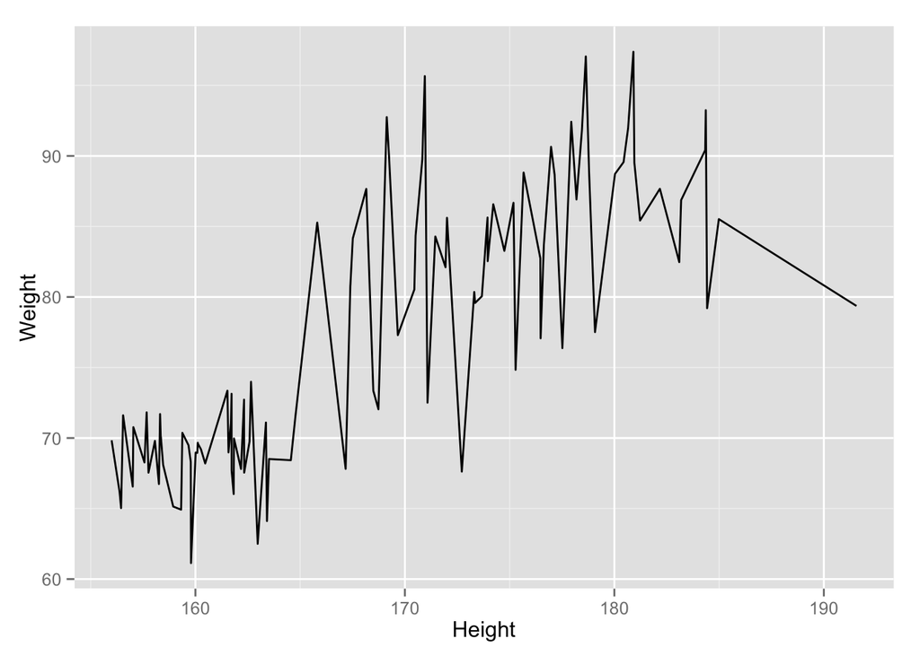

```r
pcPlot <- ggplot(data=patients_clean,
        mapping=aes(x=Height,Weight))

pcPlot_line <- pcPlot+geom_line()

pcPlot_line
```

```
## geom_smooth: method="auto" and size of largest group is <1000, so using loess. Use 'method = x' to change the smoothing method.
```

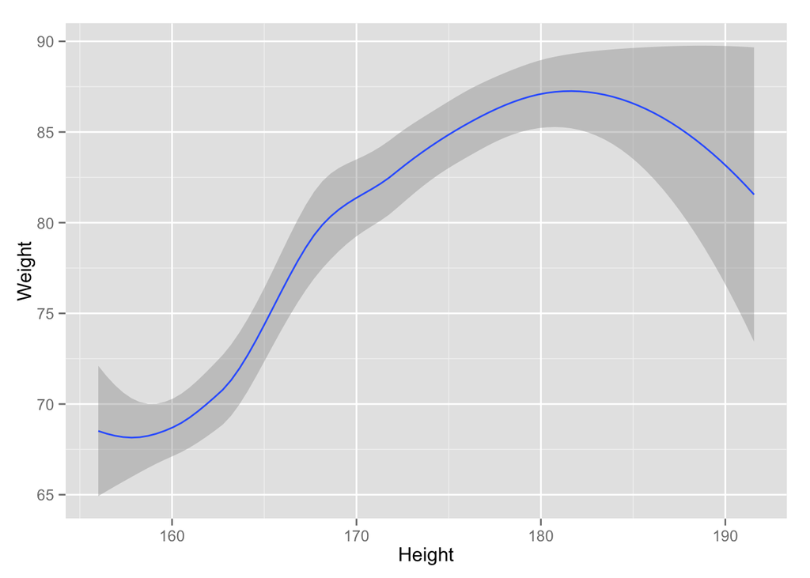

```r
pcPlot <- ggplot(data=patients_clean,
        mapping=aes(x=Height,Weight))

pcPlot_smooth <- pcPlot+geom_smooth()

pcPlot_smooth
```

### Geoms - Bar and frequency plots

```
## stat_bin: binwidth defaulted to range/30. Use 'binwidth = x' to adjust this.
```

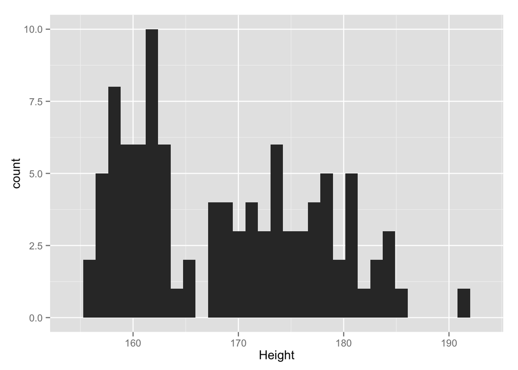

```r
pcPlot <- ggplot(data=patients_clean,
        mapping=aes(x=Height))

pcPlot_bar <- pcPlot+geom_bar()

pcPlot_bar
```

```r
# pcPlot <- ggplot(data=patients_clean,
#         mapping=aes(x=Height,))
#
# pcPlot_bar <- pcPlot+geom_bar()
#
# pcPlot_bar
```

```
## stat_bin: binwidth defaulted to range/30. Use 'binwidth = x' to adjust this.
```

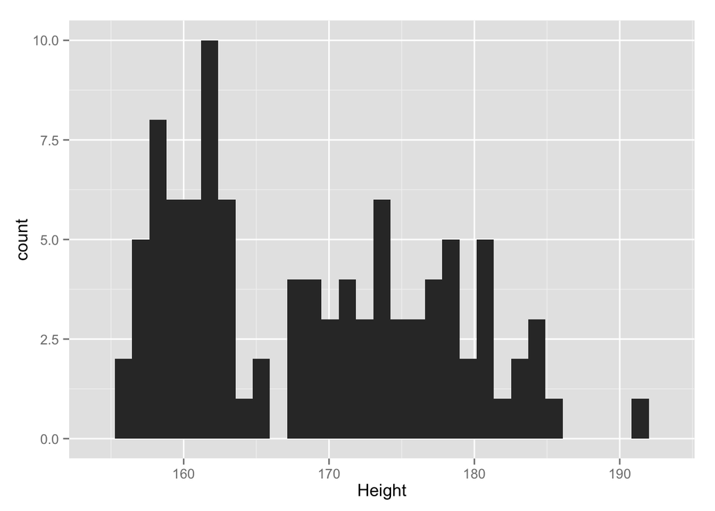

```r
pcPlot <- ggplot(data=patients_clean,
        mapping=aes(x=Height))

pcPlot_hist <- pcPlot+geom_histogram()

pcPlot_hist
```

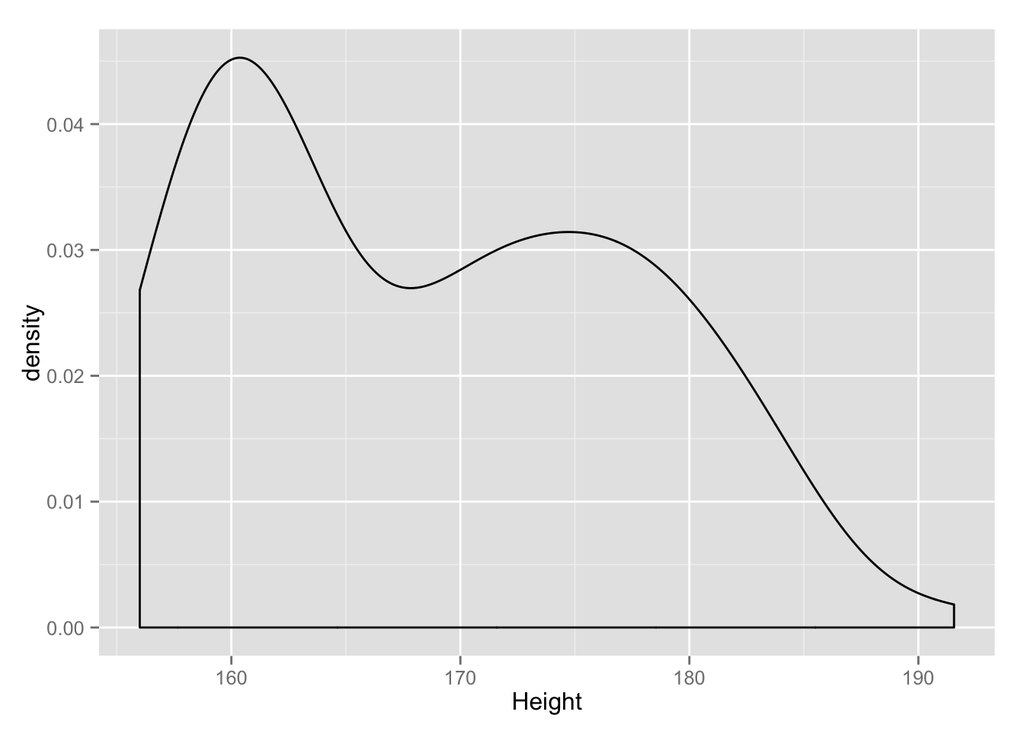

```r
pcPlot <- ggplot(data=patients_clean,
        mapping=aes(x=Height))

pcPlot_density <- pcPlot+geom_density()

pcPlot_density
```

### Geoms - Box and violin plots

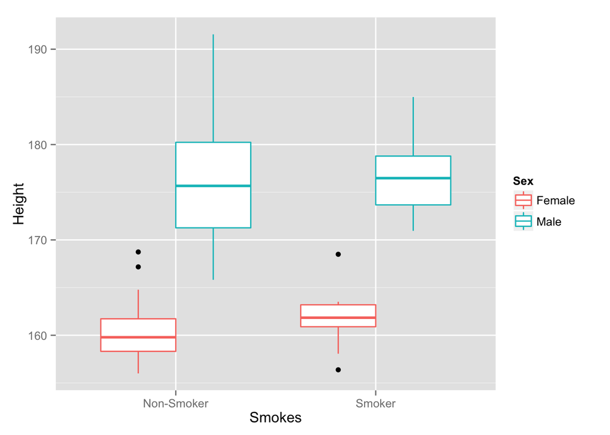

```r
pcPlot <- ggplot(data=patients_clean,
        mapping=aes(x=Smokes,y=Height,colour=Sex))

pcPlot_boxplot <- pcPlot+geom_boxplot()

pcPlot_boxplot
```

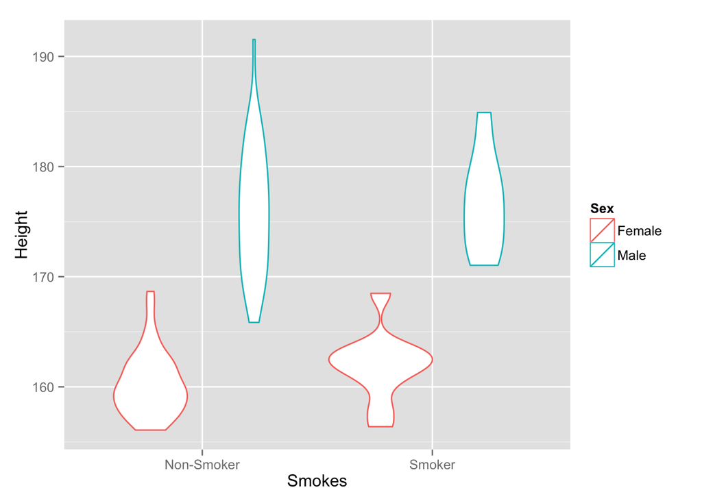

```r
pcPlot <- ggplot(data=patients_clean,
        mapping=aes(x=Smokes,y=Height,colour=Sex))

pcPlot_violin <- pcPlot+geom_violin()

pcPlot_violin
```

### Aesthetics

If we wanted to change a feature of the plot into a constant value (e.g. set colour of points to red), the we can supply the colour argument to the geom_point() function.

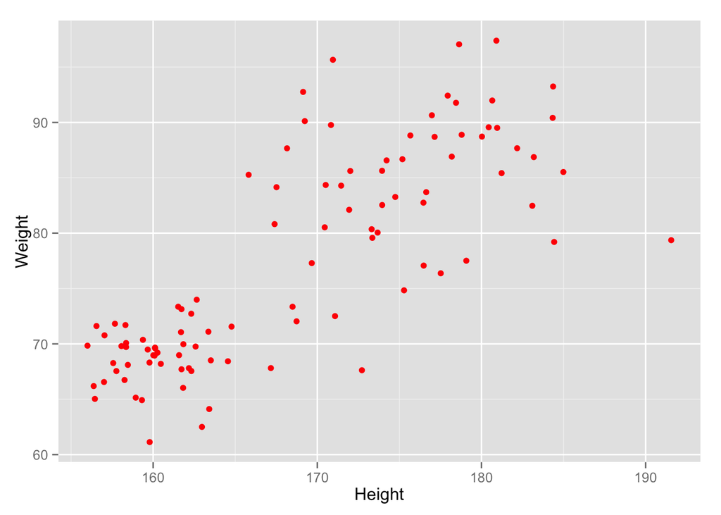

```r
pcPlot <- ggplot(data=patients_clean,
                 mapping=aes(x=Height,Weight))
pcPlot+geom_point(colour="red")
```

As we discussed earlier however, ggplot2 makes use of aesthetic mappings to assign variables in the data to properties of the plot. This allows the properties of the plot to reflect variables in the data dynamically.

In these examples we supply additional information to the aes() function to define what information to display and how it is represented in the plot.

First we can recreate the plot we saw earlier.

```r
pcPlot <- ggplot(data=patients_clean,
                 mapping=aes(x=Height,Weight))
pcPlot+geom_point()
```

[output not shown]

Now we can adjust the aes mapping by supplying an argument to the colour parameter in the aes function. (Note that ggplot2 accepts “color” or “colour” as parameter name)

This simple adjustment allows us to identify the separation of male and female measurements.

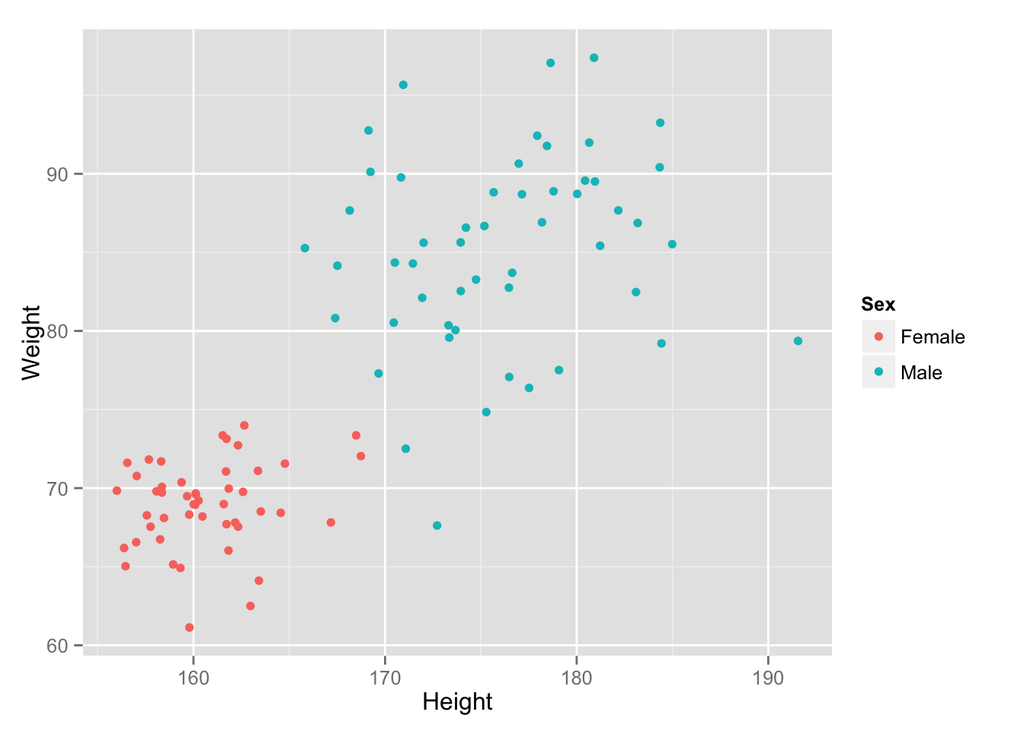

```r
pcPlot <- ggplot(data=patients_clean,
                 mapping=aes(x=Height,y=Weight,colour=Sex))
pcPlot+geom_point()
```

Similarly we can adjust the shape of points

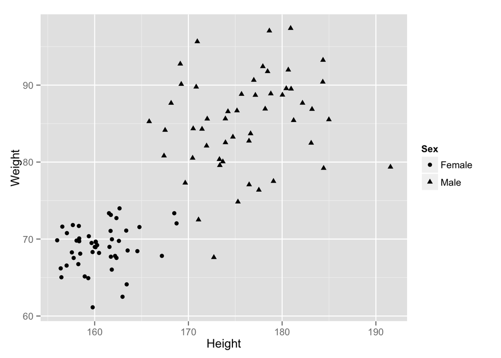

```r
pcPlot <- ggplot(data=patients_clean,
                 mapping=aes(x=Height,y=Weight,shape=Sex))
pcPlot+geom_point()
```

We can also set the aes directly in the geom_points() function as we did when specifying red. This can allow the same ggplot object to be used by different aes specification and varying geoms

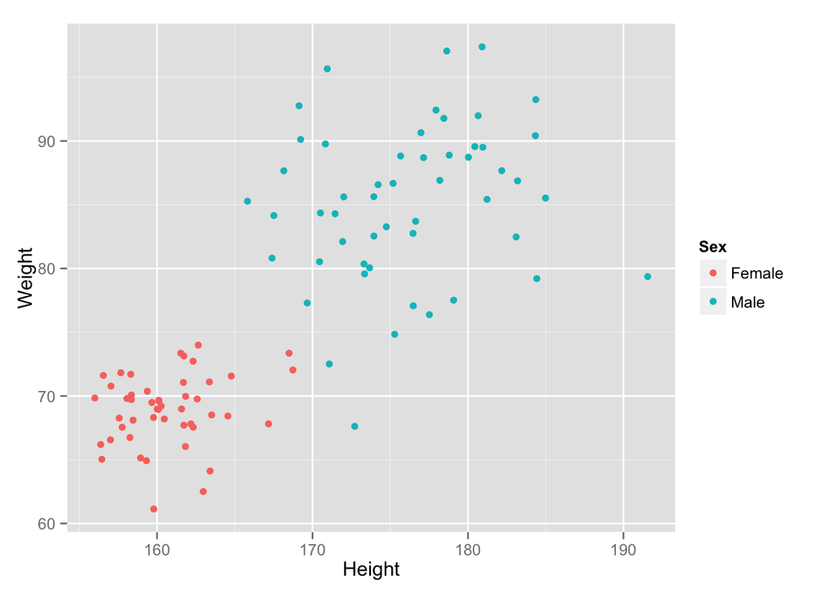

```r
pcPlot <- ggplot(data=patients_clean)
pcPlot+geom_point(aes(x=Height,y=Weight,colour=Sex))
```

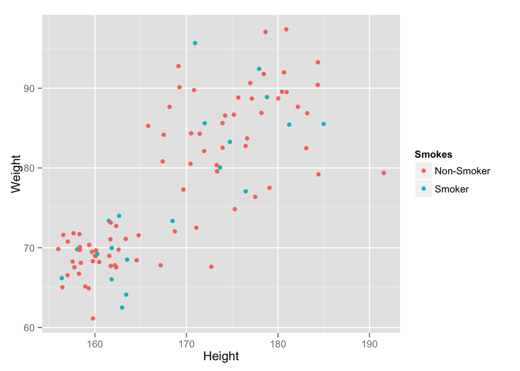

```r
pcPlot+geom_point(aes(x=Height,y=Weight,colour=Smokes))
```

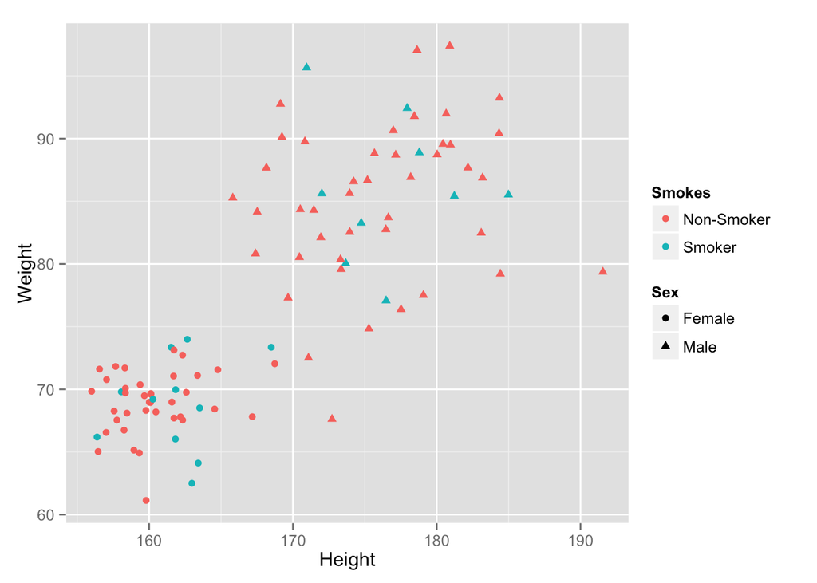

```r
pcPlot+geom_point(aes(x=Height,y=Weight,colour=Smokes,shape=Sex))
```

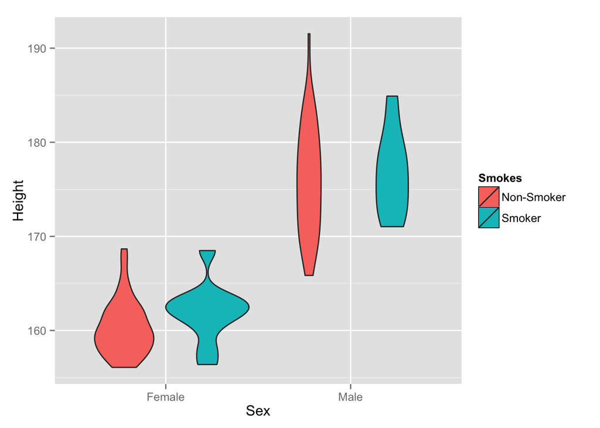

```r
pcPlot+geom_violin(aes(x=Sex,y=Height,fill=Smokes))
```

## Facets

One very useful feature of ggplot is faceting. This allows you to produce plots subsets by variables in your data.

To facet our data into multiple plots we can use the facet_wrap or facet_grid function specifying the variable we split by.

The facet_grid() is well suited to splitting the data by two factors.

Here we can plot the data with the Smokes variable as rows and Sex variable as columns

facet_grid(Rows~Columns)

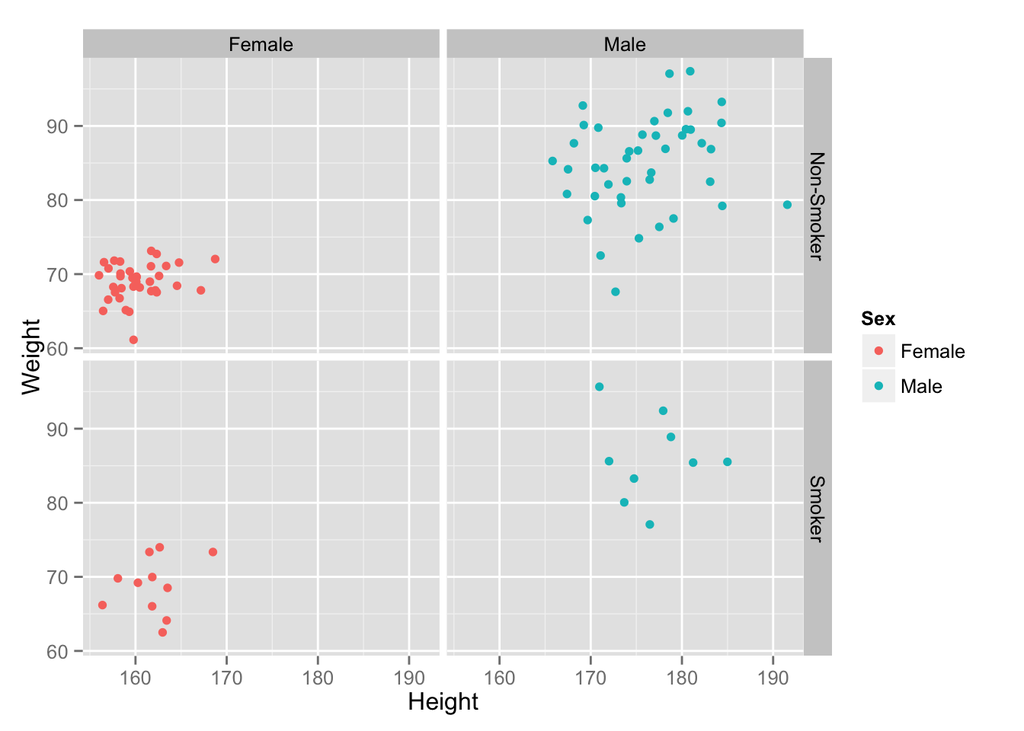

```r
pcPlot <- ggplot(data=patients_clean,aes(x=Height,y=Weight,colour=Sex))+geom_point()
pcPlot + facet_grid(Smokes~Sex)
```

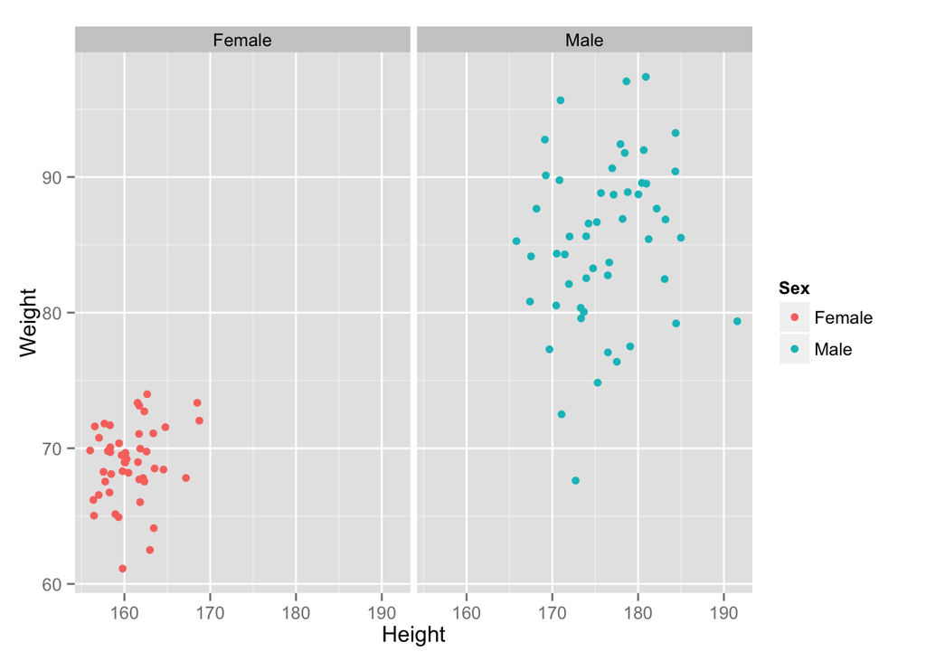

```r
pcPlot <- ggplot(data=patients_clean,aes(x=Height,y=Weight,colour=Sex))+geom_point()
pcPlot + facet_grid(~Sex)
```

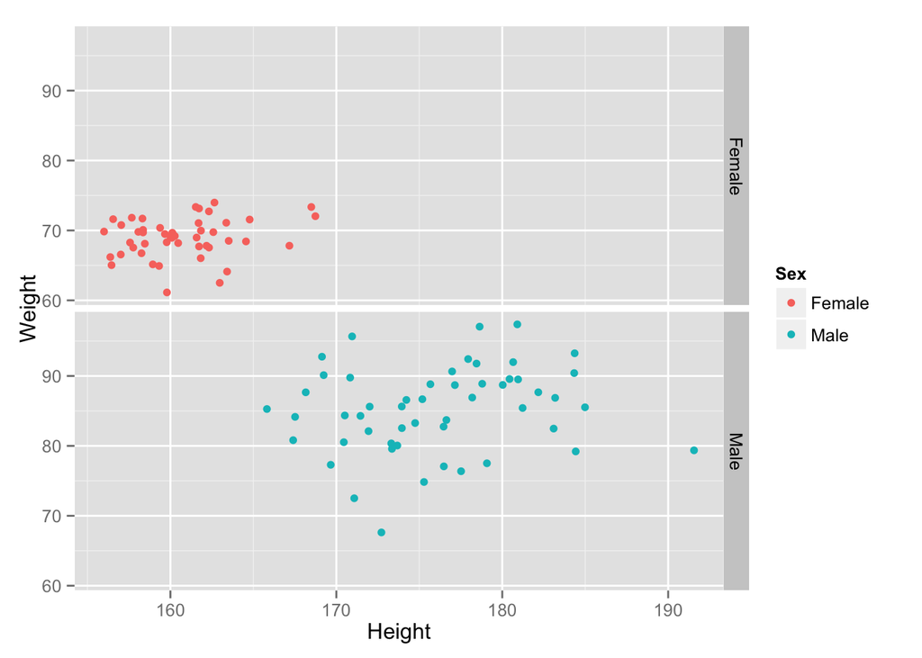

```r
pcPlot <- ggplot(data=patients_clean,aes(x=Height,y=Weight,colour=Sex))+geom_point()
pcPlot + facet_grid(Sex~.)
```

By one variable we follow as similar syntax to facet_grid()

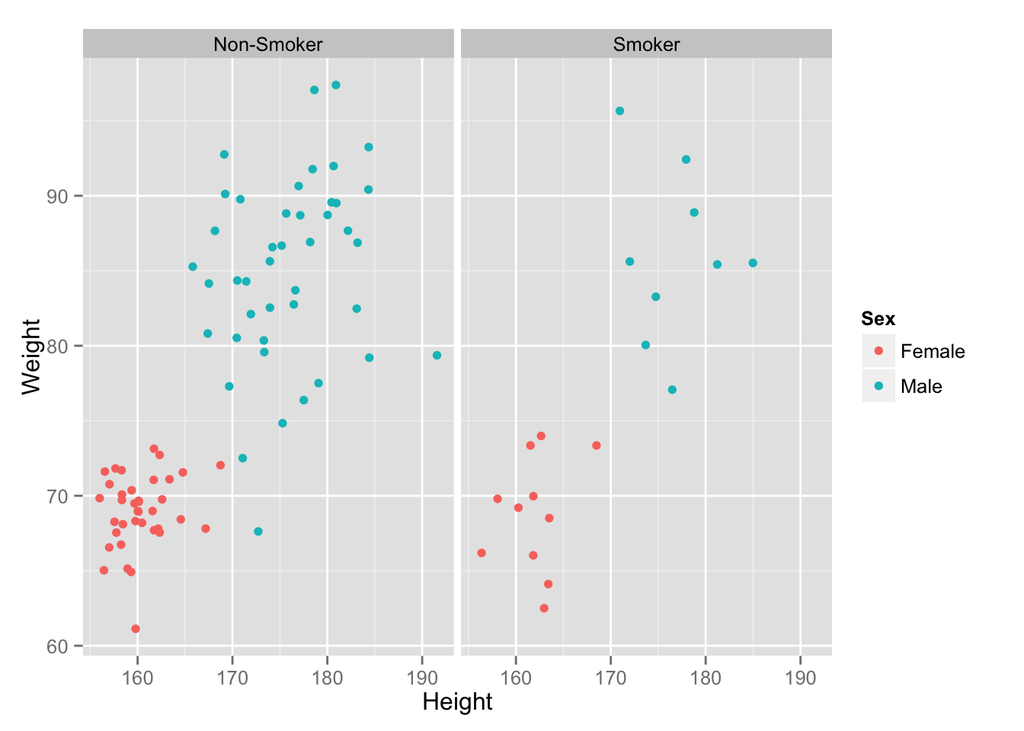

```r
pcPlot <- ggplot(data=patients_clean,aes(x=Height,y=Weight,colour=Sex))+geom_point()
pcPlot + facet_wrap(~Smokes)
```

For more complex faceting both facet_grid and facet_wrap can accept combinations of variables.

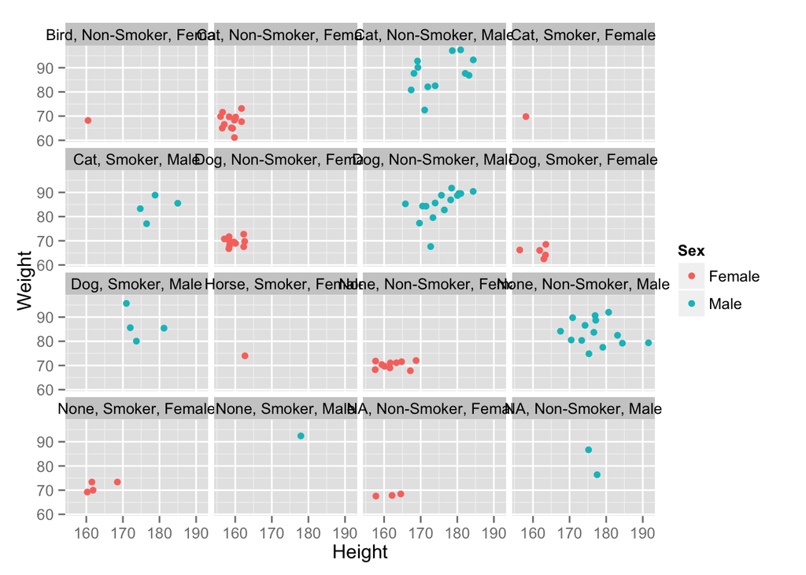

```r
pcPlot <- ggplot(data=patients_clean,aes(x=Height,y=Weight,colour=Sex))+geom_point()
pcPlot + facet_wrap(~Pet+Smokes+Sex)
```

Or in a nice grid format using facet_grid() and the Smokes variable against a combination of Gender and Pet.

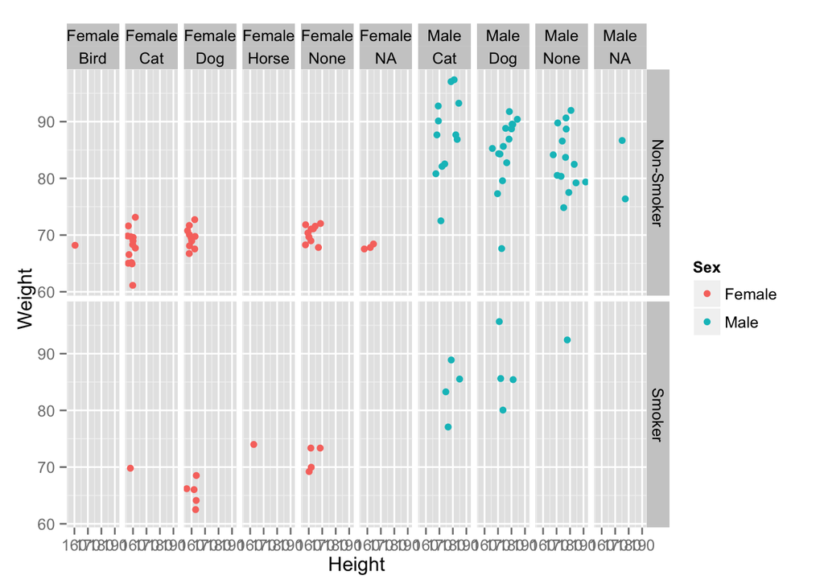

```r
pcPlot + facet_grid(Smokes~Sex+Pet)
```

## Scales

Scales and their legends have so far been handled using ggplot2 defaults. ggplot2 offers functionality to have finer control over scales and legends using the scale methods.

Scale methods are divided into by functions by combinations of

- the aesthetics they control
- the type of data mapped to

scale_**aesthetic**_**type**

Some common arguments to scale functions include -

name - The axis or legend title limits - Minimum and maximum of the scale breaks - Label/tick positions along an axis labels - Label names at each break

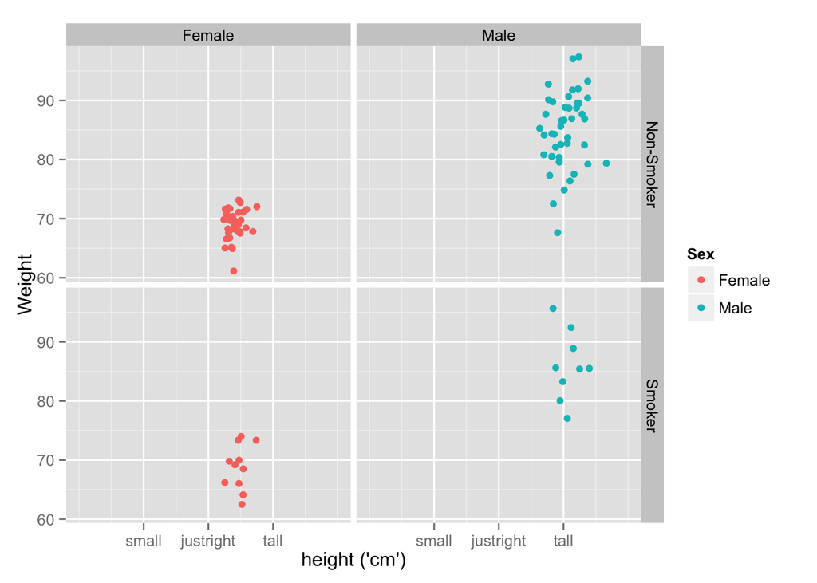

```r
pcPlot +
  geom_point() +
  facet_grid(Smokes~Sex)+
  scale_x_continuous(name="height ('cm')",limits = c(100,200),breaks=c(125,150,175),labels=c("small","justright","tall"))
```